# Exercises 09.06, morning

Author

Eleftheria Michalopoulou

These are the exercises for the [Basic Statistics and Projects in R](https://zuw.me/kurse/dt.php?kid=4474) course of the [Public Health Sciences Course Program](https://www.medizin.unibe.ch/studies/study_programs/phs_course_program) at the [University of Bern](https://www.unibe.ch/).

# Inference using proportions

## Data description and import

In the following exercises, we will use data collected by the German Breast Cancer Study Group, available in package [TH.data](https://cran.r-project.org/web/packages/TH.data/TH.data.pdf). The German breast cancer study was a multicenter randomized clinical trial including patients with primary node positive breast cancer. The aim of the study was to investigate the effectiveness of three versus six cycles of chemotherapy and of additional hormonal therapy. Here, we will only use data of of 686 women that had complete information on the variables included in the dataset. For more information and relevant references type `?GBSG2`.

```r
breastCancer <- TH.data::GBSG2

str(breastCancer)
```

```
'data.frame':   686 obs. of  10 variables:
 $ horTh   : Factor w/ 2 levels "no","yes": 1 2 2 2 1 1 2 1 1 1 ...
 $ age     : int  70 56 58 59 73 32 59 65 80 66 ...
 $ menostat: Factor w/ 2 levels "Pre","Post": 2 2 2 2 2 1 2 2 2 2 ...
 $ tsize   : int  21 12 35 17 35 57 8 16 39 18 ...
 $ tgrade  : Ord.factor w/ 3 levels "I"<"II"<"III": 2 2 2 2 2 3 2 2 2 2 ...
 $ pnodes  : int  3 7 9 4 1 24 2 1 30 7 ...
 $ progrec : int  48 61 52 60 26 0 181 192 0 0 ...
 $ estrec  : int  66 77 271 29 65 13 0 25 59 3 ...
 $ time    : int  1814 2018 712 1807 772 448 2172 2161 471 2014 ...
 $ cens    : int  1 1 1 1 1 1 0 0 1 0 ...
```

```r
head(breastCancer)
```

```
  horTh age menostat tsize tgrade pnodes progrec estrec time cens
1    no  70     Post    21     II      3      48     66 1814    1
2   yes  56     Post    12     II      7      61     77 2018    1
3   yes  58     Post    35     II      9      52    271  712    1
4   yes  59     Post    17     II      4      60     29 1807    1
5    no  73     Post    35     II      1      26     65  772    1
6    no  32      Pre    57    III     24       0     13  448    1
```

## Exercise 1

We would like to explore the occurrence of the adverse event cancer recurrence or death in women that received hormonal therapy and in women that didn’t received hormonal therapy. We will use the variables `cens` (0 = no recurrence, 1 = recurrence) and `horTh` (no = hormonal therapy not-received, yes = hormonal therapy received).

#### 1.1. Group proportions

Calculate the proportion of women that experienced the event (recurrence of cancer or death), separately for women that didn’t received hormonal therapy and for women that received hormonal therapy.

```r
Tab_horTh_recur <-  table(breastCancer$horTh, breastCancer$cens)
Tab_horTh_recur
```

```
        0   1
  no  235 205
  yes 152  94
```

```r
n_byhorTh <- rowSums(Tab_horTh_recur)

p_recur_byhorTh <- Tab_horTh_recur[, "1"] / n_byhorTh
as.matrix(p_recur_byhorTh)
```

```
         [,1]
no  0.4659091
yes 0.3821138
```

The proportion of women that experienced recurrence seems to be higher in women that didn’t receive hormonal therapy.

#### 1.2. Confidence intervals (CI)

Calculate the 95% CI for the proportions calculated in 1.1.

```r
SE_recur_byhorTh <- sqrt(p_recur_byhorTh * (1 - p_recur_byhorTh) / n_byhorTh)


lowerCI_p_recur_byhorTh <- p_recur_byhorTh - qnorm(0.975) * SE_recur_byhorTh

upperCI_p_recur_byhorTh <- p_recur_byhorTh + qnorm(0.975) * SE_recur_byhorTh

cbind(p_recur_byhorTh, lowerCI_p_recur_byhorTh, upperCI_p_recur_byhorTh)
```

```
    p_recur_byhorTh lowerCI_p_recur_byhorTh upperCI_p_recur_byhorTh
no        0.4659091               0.4192990               0.5125192
yes       0.3821138               0.3213939               0.4428337
```

#### 1.3. CI and test for difference in proportions

Calculate the difference between the proportions calculated in 1.1. and its 95% CI. Test the null hypothesis that the risk of recurrence does not differ between women who received hormonal therapy and those that didn’t.

```r
diffp_recur_byhorTh <- p_recur_byhorTh[1] - p_recur_byhorTh[2]

SE_diffp_recur_byhorTh <- sqrt(sum(SE_recur_byhorTh ^ 2))

lowerCI_diffp_recur_byhorTh <- diffp_recur_byhorTh -
  qnorm(0.975) * SE_diffp_recur_byhorTh

upperCI_diffp_recur_byhorTh <- diffp_recur_byhorTh +
  qnorm(0.975) * SE_diffp_recur_byhorTh

cbind(diffp_recur_byhorTh, lowerCI_diffp_recur_byhorTh,
      upperCI_diffp_recur_byhorTh)
```

```
   diffp_recur_byhorTh lowerCI_diffp_recur_byhorTh upperCI_diffp_recur_byhorTh
no          0.08379527                 0.007248497                    0.160342
```

```r
prop.test(cbind(Tab_horTh_recur[, 2], Tab_horTh_recur[, 1]))
```

```
    2-sample test for equality of proportions with continuity correction

data:  cbind(Tab_horTh_recur[, 2], Tab_horTh_recur[, 1])
X-squared = 4.1714, df = 1, p-value = 0.04111
alternative hypothesis: two.sided
95 percent confidence interval:
 0.004079613 0.163510927
sample estimates:
   prop 1    prop 2
0.4659091 0.3821138
```

```r
# or
chisq.test(cbind(Tab_horTh_recur[, 2], Tab_horTh_recur[, 1]))
```

```
    Pearson's Chi-squared test with Yates' continuity correction

data:  cbind(Tab_horTh_recur[, 2], Tab_horTh_recur[, 1])
X-squared = 4.1714, df = 1, p-value = 0.04111
```

Note that we are abusing the term ‘risk’ somewhat here as the measured outcome is not the occurrence of an event over a fixed period. Rather the individual follow-up time varies greatly.

## Exercise 2

We continue to explore the occurrence of recurrence in women that received hormonal therapy and in women that didn’t received hormonal therapy.

### 2.1. Risk ratios and odds ratios

Calculate the risk ratio and the odds ratio for recurrence in women who received hormonal therapy compared to women who didn’t. Compute 95% confidence intervals for these. Perform the calculations manually and using R-functions `riskratio` and `oddsratio` from the package [epitools](https://cran.r-project.org/web/packages/epitools/epitools.pdf). Compare the results produced manually with the ones produced using `epitools`.

Note that risk and odds ratios are generally calculated comparing exposed (numerator) to unexposed (denominator).

```r
## Manually ....................................................................

# first calculate the values
# RR
recurRelativeRisk <-  p_recur_byhorTh["yes"] / p_recur_byhorTh["no"]
recurRelativeRisk
```

```
      yes
0.8201467
```

```r
# OR
recurOddsRatio <-  (Tab_horTh_recur["yes", "1"]/ Tab_horTh_recur["yes", "0"]) /
  (Tab_horTh_recur["no", "1"]/Tab_horTh_recur["no", "0"])
recurOddsRatio
```

```
[1] 0.7089217
```

```r
# Confidence intervals
# RR
z<-qnorm(0.975)
se_lnRR <-  sqrt(1/Tab_horTh_recur["yes", "1"] - 1/n_byhorTh["yes"] +
                 1/Tab_horTh_recur["no", "1"] - 1/n_byhorTh["no"])
lowerCI_recurRelativeRisk <- exp(log(recurRelativeRisk)-z*se_lnRR)
upperCI_recurRelativeRisk <- exp(log(recurRelativeRisk)+z*se_lnRR)
cbind(recurRelativeRisk,lowerCI_recurRelativeRisk, upperCI_recurRelativeRisk)
```

```
    recurRelativeRisk lowerCI_recurRelativeRisk upperCI_recurRelativeRisk
yes         0.8201467                 0.6797391                 0.9895571
```

```r
# OR
se_lnOR <-  sqrt(1/Tab_horTh_recur["yes", "1"] + 1/Tab_horTh_recur["yes", "0"] +
                 1/Tab_horTh_recur["no", "1"] + 1/Tab_horTh_recur["no", "0"])
lowerCI_recurOddsRatio <- exp(log(recurOddsRatio)-z*se_lnOR)
upperCI_recurOddsRatio <- exp(log(recurOddsRatio)+z*se_lnOR)
cbind(recurOddsRatio,lowerCI_recurOddsRatio, upperCI_recurOddsRatio)
```

```
     recurOddsRatio lowerCI_recurOddsRatio upperCI_recurOddsRatio
[1,]      0.7089217              0.5157317              0.9744795
```

```r
## R-functions .................................................................

riskratio(Tab_horTh_recur, correction = TRUE)
```

```
$data

          0   1 Total
  no    235 205   440
  yes   152  94   246
  Total 387 299   686

$measure
     risk ratio with 95% C.I.
       estimate     lower     upper
  no  1.0000000        NA        NA
  yes 0.8201467 0.6797391 0.9895571

$p.value
     two-sided
      midp.exact fisher.exact chi.square
  no          NA           NA         NA
  yes 0.03396137   0.03694663 0.04111128

$correction
[1] TRUE

attr(,"method")
[1] "Unconditional MLE & normal approximation (Wald) CI"
```

```r
riskratio(Tab_horTh_recur, correction = TRUE, rev = "rows") # what does this RR mean?
```

```
$data

          0   1 Total
  yes   152  94   246
  no    235 205   440
  Total 387 299   686

$measure
     risk ratio with 95% C.I.
      estimate    lower    upper
  yes 1.000000       NA       NA
  no  1.219294 1.010553 1.471153

$p.value
     two-sided
      midp.exact fisher.exact chi.square
  yes         NA           NA         NA
  no  0.03396137   0.03694663 0.04111128

$correction
[1] TRUE

attr(,"method")
[1] "Unconditional MLE & normal approximation (Wald) CI"
```

```r
# calculated manually

oddsratio(Tab_horTh_recur)
```

```
$data

          0   1 Total
  no    235 205   440
  yes   152  94   246
  Total 387 299   686

$measure
     odds ratio with 95% C.I.
      estimate     lower     upper
  no  1.000000        NA        NA
  yes 0.709566 0.5150453 0.9744184

$p.value
     two-sided
      midp.exact fisher.exact chi.square
  no          NA           NA         NA
  yes 0.03396137   0.03694663 0.03378074

$correction
[1] FALSE

attr(,"method")
[1] "median-unbiased estimate & mid-p exact CI"
```

The risk of experiencing recurrence in women that received hormonal therapy compared to women that didn’t receive hormonal therapy is 0.82 (95%-CI: 0.68 0.99), and the corresponding odds ratio is 0.71 (95%-CI: 0.51, 0.97) . You can play around with the argument `rev` to perform the comparison of your preference, e.g. if you wanted to compare untreated to treated.

## Exercise 3

### 3.1. Event rates

Calculate the rates for recurrence or death and their 95% CIs in women that didn’t receive hormonal therapy and in women that received hormonal therapy. Perform the calculation manually and using the cipoisson function of the survival package.

```r
## Manually ....................................................................

breastCancer$time_years <- breastCancer$time / 365.25

recur_byhorTh <- aggregate(cens ~ horTh, data = breastCancer, FUN = sum)

pYr_byhorTh <- aggregate(time_years ~ horTh, data = breastCancer, FUN = sum)

recur_pYr_byhorTh <- merge(recur_byhorTh, pYr_byhorTh, by = "horTh")

recur_pYr_byhorTh$rate <- recur_pYr_byhorTh$cens / recur_pYr_byhorTh$time_years

SE_logrecurRate <- 1 / sqrt(recur_pYr_byhorTh$cens)

recur_pYr_byhorTh$rate_lowerCI <- exp(
  log(recur_pYr_byhorTh$rate) - 1.96 * SE_logrecurRate)

recur_pYr_byhorTh$rate_upperCI <- exp(
  log(recur_pYr_byhorTh$rate) + 1.96 * SE_logrecurRate)

recur_pYr_byhorTh
```

```
  horTh cens time_years      rate rate_lowerCI rate_upperCI
1    no  205  1276.6078 0.1605818   0.14003764    0.1841399
2   yes   94   835.3703 0.1125249   0.09192899    0.1377353
```

```r
## R-functions .................................................................

cipoisson(k = recur_pYr_byhorTh$cens, time = recur_pYr_byhorTh$time_years)
```

```
          lower    upper
[1,] 0.13935087 0.184133
[2,] 0.09093161 0.137702
```

We estimate the rate of recurrence or death among woman not receiving hormonal therapy to be 16.1 per 100 person years (or 16 recurrences among 100 woman per year). We are 95% confident that this number will be between 14.0 and 18.4. The corresponding rate among woman receiving hormonal therapy is 11.3 per 100 person years (95% CI: 9.1, 13.8).

### 3.2. Rate ratio

Calculate the rate ratio for recurrence or death and its 95% CI in women that received hormonal therapy compared women that didn’t receive hormonal therapy.

```r
# Manually
recurRateRatio <- recur_pYr_byhorTh$rate[recur_pYr_byhorTh$horTh == "yes"] /
  recur_pYr_byhorTh$rate[recur_pYr_byhorTh$horTh == "no"]

SE_logrecurRateRatio <- sqrt(
  1 / recur_pYr_byhorTh$cens[recur_pYr_byhorTh$horTh == "yes"] +
    1 / recur_pYr_byhorTh$cens[recur_pYr_byhorTh$horTh == "no"])

lowerCI_recurRateRatio <- exp(log(recurRateRatio) - 1.96 * SE_logrecurRateRatio)

upperCI_recurRateRatio <- exp(log(recurRateRatio) + 1.96 * SE_logrecurRateRatio)

cbind(recurRateRatio, lowerCI_recurRateRatio, upperCI_recurRateRatio)
```

```
     recurRateRatio lowerCI_recurRateRatio upperCI_recurRateRatio
[1,]      0.7007328               0.548935              0.8945076
```

```r
## R-functino
rateratio(x = recur_pYr_byhorTh$cens, y = recur_pYr_byhorTh$time_years)
```

```
$data
          Outcome
Predictor  recur_pYr_byhorTh$cens recur_pYr_byhorTh$time_years
  Exposed1                    205                    1276.6078
  Exposed2                     94                     835.3703
  Total                       299                    2111.9781

$measure
          rate ratio with 95% C.I.
Predictor  estimate     lower     upper
  Exposed1 1.000000        NA        NA
  Exposed2 0.701408 0.5471781 0.8924633

$p.value
          two-sided
Predictor   midp.exact        wald
  Exposed1          NA          NA
  Exposed2 0.003710077 0.004104184

attr(,"method")
[1] "Median unbiased estimate & mid-p exact CI"
```

The data suggest that hormone therapy is associated with a relative decrease of the rate of the adverse outcome by 30% (95%-CI: 11%,45%).

## Exercise 4

### 3.1. Recurrence-free survival curves

Use the Kaplan-Meier estimator to calculate the recurrence-free survival of women whoe received and of women who didn’t receive hormonal therapy. Use the R-function `survfit()` from package [survival](https://cran.r-project.org/web/packages/survival/survival.pdf). Inspect the `summary()` of the `survfit()` output and plot the recurrence-free survival curves according to the exposure to hormonal therapy.

```r
KM_recur_byhorTh <- survfit(Surv(time_years, cens) ~ horTh,
                            data = breastCancer)

summary(KM_recur_byhorTh)
```

```
Call: survfit(formula = Surv(time_years, cens) ~ horTh, data = breastCancer)

                horTh=no
  time n.risk n.event survival std.err lower 95% CI upper 95% CI
 0.197    430       1    0.998 0.00232       0.9931        1.000
 0.268    429       1    0.995 0.00328       0.9889        1.000
 0.309    428       1    0.993 0.00401       0.9852        1.000
 0.329    427       1    0.991 0.00463       0.9817        1.000
 0.438    425       1    0.988 0.00517       0.9783        0.999
 0.468    424       1    0.986 0.00566       0.9750        0.997
 0.474    423       1    0.984 0.00611       0.9718        0.996
 0.479    422       1    0.981 0.00652       0.9687        0.994
 0.496    420       1    0.979 0.00691       0.9656        0.993
 0.523    419       1    0.977 0.00728       0.9625        0.991
 0.534    418       1    0.974 0.00763       0.9595        0.989
 0.561    416       1    0.972 0.00796       0.9565        0.988
 0.611    415       1    0.970 0.00828       0.9536        0.986
 0.638    414       1    0.967 0.00859       0.9507        0.984
 0.660    413       1    0.965 0.00888       0.9477        0.983
 0.663    412       1    0.963 0.00916       0.9449        0.981
 0.676    411       1    0.960 0.00943       0.9420        0.979
 0.682    410       1    0.958 0.00970       0.9391        0.977
 0.687    409       1    0.956 0.00995       0.9363        0.975
 0.745    408       1    0.953 0.01020       0.9335        0.973
 0.769    405       2    0.949 0.01068       0.9279        0.970
 0.780    403       2    0.944 0.01113       0.9223        0.966
 0.789    401       1    0.942 0.01135       0.9195        0.964
 0.802    400       1    0.939 0.01156       0.9168        0.962
 0.835    399       1    0.937 0.01177       0.9140        0.960
 0.841    398       1    0.934 0.01198       0.9113        0.958
 0.843    397       1    0.932 0.01217       0.9085        0.956
 0.865    395       1    0.930 0.01237       0.9058        0.954
 0.901    393       1    0.927 0.01256       0.9031        0.952
 0.920    392       1    0.925 0.01275       0.9004        0.950
 0.925    391       3    0.918 0.01330       0.8922        0.944
 0.939    388       1    0.916 0.01347       0.8895        0.942
 0.942    387       1    0.913 0.01364       0.8868        0.940
 0.953    386       1    0.911 0.01381       0.8841        0.938
 0.958    385       1    0.908 0.01398       0.8815        0.936
 0.966    384       1    0.906 0.01414       0.8788        0.934
```

[output cut: 235 more lines]

```
 4.088     98       1    0.627 0.03388        0.564        0.697
 4.112     96       1    0.620 0.03415        0.557        0.691
 4.164     93       1    0.613 0.03443        0.549        0.685
 4.493     87       1    0.606 0.03475        0.542        0.678
 4.597     83       1    0.599 0.03509        0.534        0.672
 4.827     69       1    0.590 0.03564        0.524        0.664
 4.947     65       1    0.581 0.03623        0.514        0.657
 5.251     44       1    0.568 0.03774        0.499        0.647
 5.407     41       1    0.554 0.03928        0.482        0.637
 5.413     40       1    0.540 0.04066        0.466        0.626
 5.446     38       1    0.526 0.04201        0.450        0.615
 5.517     32       1    0.510 0.04379        0.431        0.603
 5.525     30       1    0.493 0.04551        0.411        0.590
 5.558     27       1    0.474 0.04734        0.390        0.577
 6.494     13       1    0.438 0.05603        0.341        0.563
```

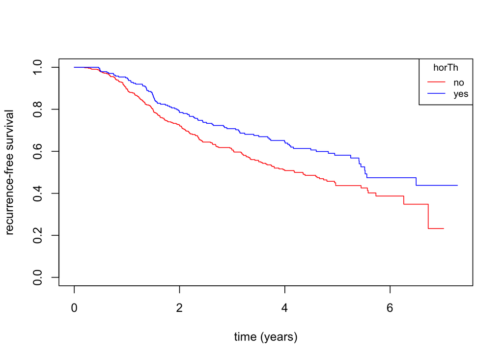

```r
plot(KM_recur_byhorTh, col = c("red", "blue"), xlab = "time (years)",
     ylab = "recurrence-free survival")
legend("topright", lty = c(1, 1), col = c("red", "blue"),
       legend = c("no", "yes"), title = "horTh", cex = 0.8)
```

The recurrence-free survival curve of women that didn’t received hormonal therapy is always below the recurrence-free survival curve of women that received hormonal therapy (except maybe during the first months of follow-up). It seems that women that didn’t received hormonal therapy have higher chances of experiencing recurrence per year compared to women that received hormonal therapy.

### 3.2. Log-rank test

Perform a test for difference in the recurrence-free survival curves between the treatment groups. Is there evidence for a difference between the recurrence-free survival curves?

```r
survdiff(Surv(time, cens) ~ horTh, data = breastCancer, rho = 0)
```

```
Call:
survdiff(formula = Surv(time, cens) ~ horTh, data = breastCancer,
    rho = 0)

            N Observed Expected (O-E)^2/E (O-E)^2/V
horTh=no  440      205      180      3.37      8.56
horTh=yes 246       94      119      5.12      8.56

 Chisq= 8.6  on 1 degrees of freedom, p= 0.003
```

There is evidence for a difference in the recurrence-free survival curves of women that received and of women that didn’t receive hormonal therapy (p= 0.003).